# Fun with R: Ecological data analysis in R

Vianney Denis

2020/12/8

# Topic 8 - Multivariate analyses

```r
library(vegan)
library(ade4)
library(gclus)
library(qgraph)
library(factoextra)
```

```r
knitr::purl("Topic_8_multivariate.Rmd", documentation = F)
```

Ecological phenomena are inherently complex, and it is rare that a single variable is sufficient to describe an ecological system. Therefore, it is common to deal with:

- **multiple response variable**
- multiple explanatory variables

Multivariate analyses may reveal patterns that would not be detectable by combination of univariate methods.

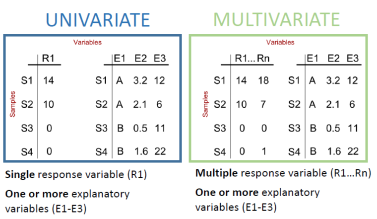

**Comparaison between univariate and multivariate analyses**: multivariate methods allow the evaluation of all response variables simultaneously. R<sub>1,…,i</sub>: Response variables; E<sub>1,…,i</sub>: Explanatory variables; S<sub>1,…,i</sub>: Samples

## Applications

Five types of scientific inquiries usually suit to the application of multivariate methods.

- **Data reduction or structural simplification**: summarize multiple variables through a comparatively smaller set of ‘synthetic’ variables. *Ex: Principal Component Analysis (PCA)*
- **Sorting and grouping**: many ecological questions are concerned with the similarity or dissimilarity. *Ex:Cluster analysis, non Metric Dimensional Scaling (nMDS)*
- **Investigation of the dependence among variables**: dependence among response variables, among explanatory variables, or among both. *Ex: Redundancy analysis and other constrained analysis*
- **Prediction**: once the dependence detected and characterized multivariate models may be constructed in a very similar as we did before with univariate models.
- **Hypothesis testing**: detect and test pattern in the data (be careful of data dredging) . *Ex: MANOVA, PERMANOVA, ANOSIM*

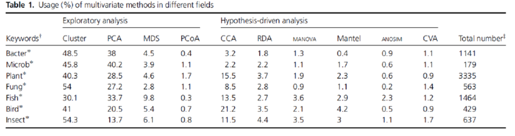

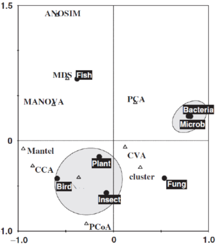

**Correspondance analysis of methods usage in various scientific fields**: axis 1 differentiate microscopic from macroscopic organisms. Cluster, PCA, etc are exploratory methods and apply preferentially to small organisms.

## Typical Data Structure

In ecology, ‘typical’ data structure will be:

- objects in row (e.g. samples can be sites, time periods, etc.)
- measured variables for those objects in columns (e.g. species, environmental parameters, etc.)

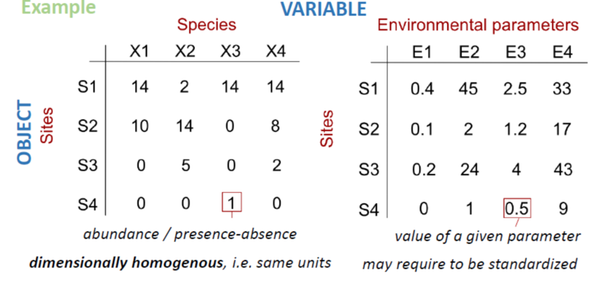

*Important note*: observations on object are not necessarily **independent** on those made on another object, and a mixture of dependent and independent objects is possible e.g. site and year

## Data transformation

Measured variables can be binary, quantitative, qualitative, rank-ordered, or even a mixture of them.

If variables do not have uniform scale (e.g. environmental parameters measured in different units or scales), they usually have to be transformed before performing further analyses.

- **Standardization**: provides dimensionless variables and removes the influence of magnitude differences between scales and units
- **Normalization**: aims at correcting the distribution shapes of certain variables.
  - `arcsin (x)` *family of transformations for percentage and proportions*
  - `log (x + constant)` *for variables departing moderately from normal distribution*
  - `sqrt (x + constant)`*for variables departing slightly from normal distribution*
  - **Hellinger transformation** to make data containing many zeros suitable for PCA or RDA, the ‘double zeros’ problem.
  - **Chord transformation** to give less weight to rare species (especially when rare species are not truly rare)
  - …

The function `decostand` from the `vegan` package offers an easy way to transform your data. The `varespec` data frame has **24 rows** and **44 columns**. Columns are estimated cover values of **44 lichen species**. The variable names are formed from the scientific names, and are self explanatory for anybody familiar with vegetation type / lichen species.

```r
# ?varespec
data (varespec)
varespec[1:5,1:5]
```

```
##    Callvulg Empenigr Rhodtome Vaccmyrt Vaccviti
## 18     0.55    11.13     0.00     0.00    17.80
## 15     0.67     0.17     0.00     0.35    12.13
## 24     0.10     1.55     0.00     0.00    13.47
## 27     0.00    15.13     2.42     5.92    15.97
## 23     0.00    12.68     0.00     0.00    23.73
```

```r
# log,  hellinger, and presence/absence transformations
varespec.log<-decostand(varespec,'log')
varespec.hell<-decostand(varespec,'hellinger')
varespec.pa<-decostand(varespec,'pa')
varespec.pa [1:5,1:5]
```

```
##    Callvulg Empenigr Rhodtome Vaccmyrt Vaccviti
## 18        1        1        0        0        1
## 15        1        1        0        1        1
## 24        1        1        0        0        1
## 27        0        1        1        1        1
## 23        0        1        0        0        1
```

## Ressemblance

- Most methods of multivariate analysis are **explicitly** or **implicitly** based on the comparison of all possible pairs of objects or descriptors.
- Comparison takes the form of association measures which are assembled in a square and symmetrical association matrix of dimension $n$ x $n$ when objects are compared, or $p$ x $p$ when variables are compared. The choice of a suitable **association coefficient** is crucial for further analysis.
- When pairs of objects are compared, the analysis is said to be in **Q mode**.When pairs of descriptors are compared, the analysis is said to be in **R mode**.

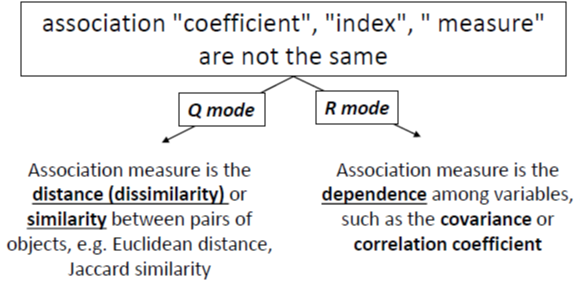

### Q mode

Virtually, all distance or similarity measures used in ecology are symmetric: the coefficient between pairs of objects is the same!

But whatto deal with **double-zeros**?

- the **zero value** has the **same meaning** as any other values (*e.g. 0mg/L of O2 in deep anoxic layer of a lake*)
- the **zero value** in matrix of species abundances (or presence-absence) can **not** always be counted as an indication of **resemblance** (presence has an ecological meaning, but no conclusions on the absence: e.g. *is the absence of a given nationality in this class means that no students from this specific country are in NTU? And is it an element to evaluate the similarity with other university (high similarity because many nationalities probably absent ? No, but at same sample size 1/0 becomes informative*)

Because of the **double-zeros** problem, 2 classes of association measures exist based on how they deal with this issue".

- The **symmetrical coefficients** will consider the information from the double-zero (also called ‘negative matched’).
- The **asymmetrical coefficients** will ignore the information send from the double-zero.

When analyzing species data, it is often recommended to use asymmetrical coefficients unless you have reason to consider each double absence in the matrix (*e.g. controlled experiment with known community composition or ecologically homogenous areas with disturbed zones*)

#### **Presence/absence-based dissimilarity metrics**

We use **Jaccard Similarity (S<sub>7</sub>)** to find similarities between sets. So first, let’s learn the very basics of sets.

[figure not shown]

[figure not shown]

Now going back to Jaccard similarity.The Jaccard similarity measures similarity between finite sample sets, and is defined as the cardinality of the intersection of sets divided by the cardinality of the union of the sample sets. Suppose you want to find jaccard similarity between two sets A and B it is the ration of cardinality of A ∩ B and A ∪ B.

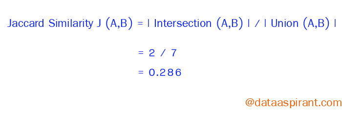

Other distances applying to presence-Absence data: Sørensen (S<sub>8</sub>), Ochiai (S<sub>14</sub>)

#### **Abundance-based dissimilarity metrics**

When your community data samples include abundance information (as opposed to simple presence-absence) you have a wider choice of metrics to use in calculating (dis)similarity.

When you have abundance data your measures of (dis)similarity are a bit more “refined” and you have the potential to pick up patterns in the data that you would otherwise not see using presence-absence data.

There are many metrics that you might use to explore (dis)similarity. Four of them are particularly common:

- Bray-Curtis
- Canberra
- Manhattan
- Euclidean

You can get the spreadsheet here to examine how to compute them in details

**Euclidean distance (D<sub>2</sub>)** is the most commonly-used of our distance measures. For this reason, Euclidean distance is often just to referred to as “distance”. When data is dense or continuous, this is the best proximity measure. The Euclidean distance between two points is the length of the path connecting them.This distance between two points is given by the Pythagorean theorem.

[figure not shown]

Here the abundance of a species from one sample is subtracted from its counterpart in the other sample. Instead of ignoring the sign, the result is squared (which gives a positive value):

$E_d=\sqrt{\sum (x_i-y_j)^2}$

**Manhattan distance** is a metric in which the distance between two points is the sum of the absolute differences of their Cartesian coordinates. In simple way of saying it is the absolute sum of difference between the x-coordinates and y-coordinates. Suppose we have a Point A and a Point B: if we want to find the Manhattan distance between them, we just have to sum up the absolute x-axis and y–axis variation. We find the Manhattan distance between two points by measuring along axes at right angles.

[figure not shown]

This is the simplest dissimilarity metric to compute:

$CB_d = \sum|x_i-x_j|$

**Bray-Curtis (D<sub>14</sub>)** dissimilarity is the **golden** ditance metric in ecology.At first, you subtract the abundance of one species in a sample from its counterpart in the other sample but ignore the sign. The second component is the abundance of a species in one sample added to the abundance of its counterpart in the second sample. If a species is absent, then its abundance should be recorded as 0 (zero).

$BC_d = \frac {\sum |x_i-x_j|}{\sum(x_i+x_j)}$

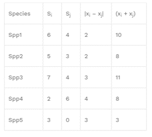

The **Canberra** dissimilarity uses the same components as Bray-Curtis but the components are summed differently:

$C_d = \sum \frac { |x_i-x_j|}{(x_i+x_j)}$

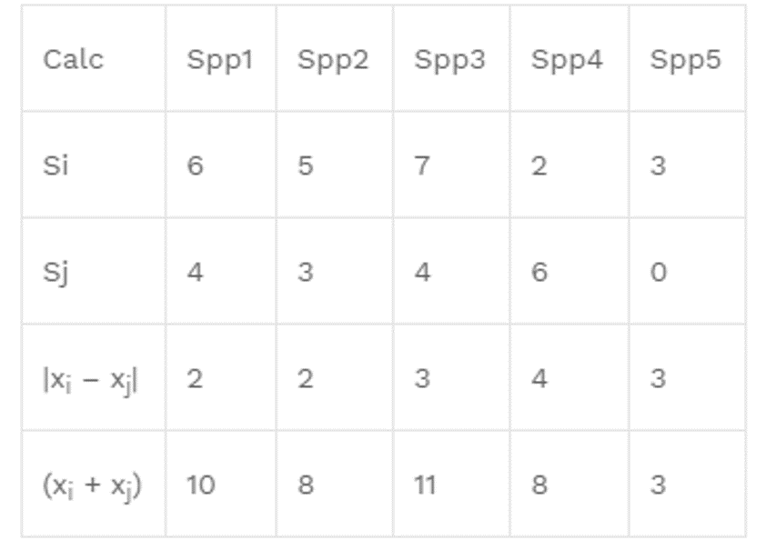

Many other ‘distances’ exist, each with their code

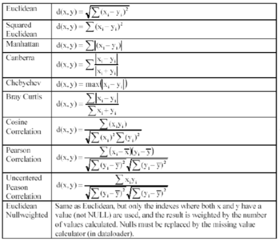

Those distance can be computed from am un-transformed or transformed matrix.

#### Computation

The functions `vegdist` from the `vegan`package and `dist` from the `stats` package compute dissimilarity indices useful and popular among community ecologists.

```r
# using varespec dataset
spe<-varespec

# quantitative data
# Bray-Curtis dissimilarity matrix on raw data
spe.db <- vegdist(spe)
head(spe.db)
```

```
## [1] 0.5310021 0.6680661 0.5621247 0.3747078 0.5094738 0.6234419
```

```r
# Bray-Curtis dissimilarity matrix on log-transformed data
spe.dbln <- vegdist(log1p(spe)) # log(x+1)
head(spe.dbln)
```

```
## [1] 0.3619358 0.4969291 0.3853004 0.3145055 0.3152830 0.3932524
```

```r
# Chord distance matrix
spe.norm<-decostand(spe,'nor')
spe.dc <- vegdist(spe.norm)
head(spe.dc)
```

```
## [1] 0.5518126 0.6834930 0.5978450 0.3793678 0.4968567 0.6448499
```

```r
# Hellinger distance matrix
spe.hel<-decostand(spe,'hel')
spe.dh <- vegdist(spe.hel)
head(spe.dh)
```

```
## [1] 0.3613332 0.5038012 0.4264724 0.3032106 0.3319945 0.4187854
```

```r
# quantitative data with a clear interpretation of double zeros use Euclidean distance D1
# using environmental dataset varechem
data(varechem)
env <- varechem
env.st<-decostand(env,'stan') # standardized using decostand or scale(env)
env.de<-vegdist(env.st,method='euc') # then compute D1

# binary data
# Jaccard dissimilarity matrix using vegdist()
spe.dj1 <- vegdist(spe,'jac',binary=T)# binary perform presence/absence standardization before analysis
head(spe.dj1)
```

```
## [1] 0.3333333 0.4705882 0.5000000 0.3333333 0.4166667 0.4000000
```

```r
# Jaccard dissimilarity matrix using dist()
spe.dj2 <- dist(spe,'binary')
head(spe.dj2)
```

```
## [1] 0.3333333 0.4705882 0.5000000 0.3333333 0.4166667 0.4000000
```

```r
# Sorensen dissimilarity matrix using vegdist()
spe.ds<-vegdist(spe,binary=T)
head(spe.ds)
```

```
## [1] 0.2000000 0.3076923 0.3333333 0.2000000 0.2631579 0.2500000
```

```r
# also see Ochiai dissimilarity matrix with dist.binary() from the ade4 package
spe.och<-dist.binary(spe, method=7)
head(spe.och)
```

```
## [1] 0.4458781 0.5504882 0.5757576 0.4458781 0.5128786 0.4995210
```

#### Matrix visualization

Using the package `gclus` and the function `coldiss` (Borcard et al. 2011) dissimilarities can be easily visualized in a heat map

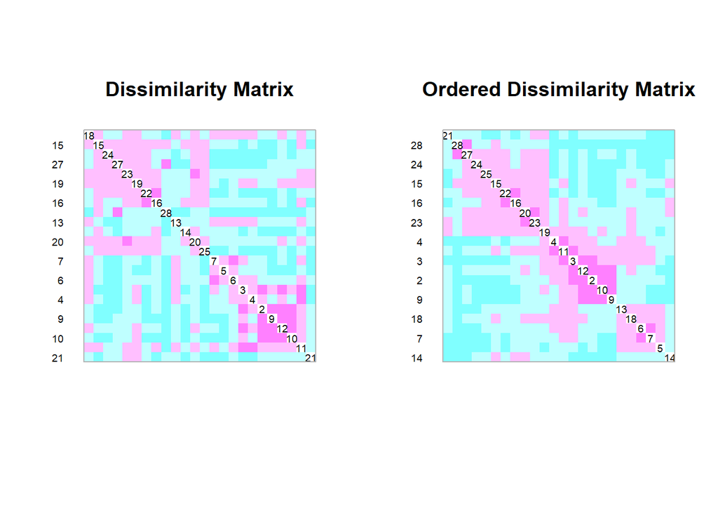

```r
library(gclus)
source('https://www.dipintothereef.com/uploads/3/7/3/5/37359245/coldiss.r') # import coldiss () function  (Borcard et al. 2011)
coldiss(spe.db,byrank=F,diag=T) # for the bc dissimilarity on raw data
```

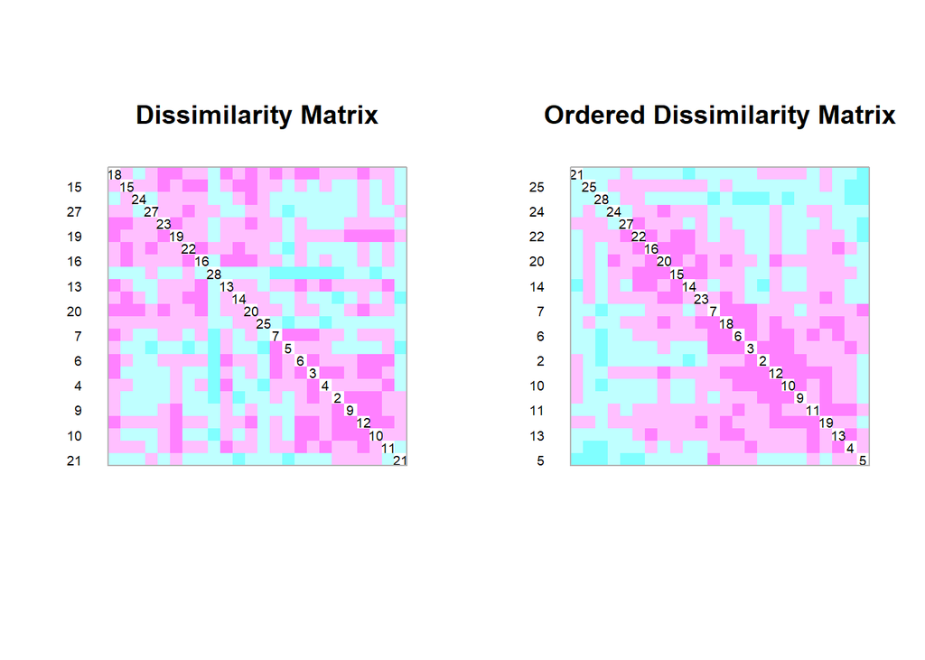

```r
coldiss(spe.dbln,byrank=F,diag=T) # for the bc dissimilarity on log-transformed data
```

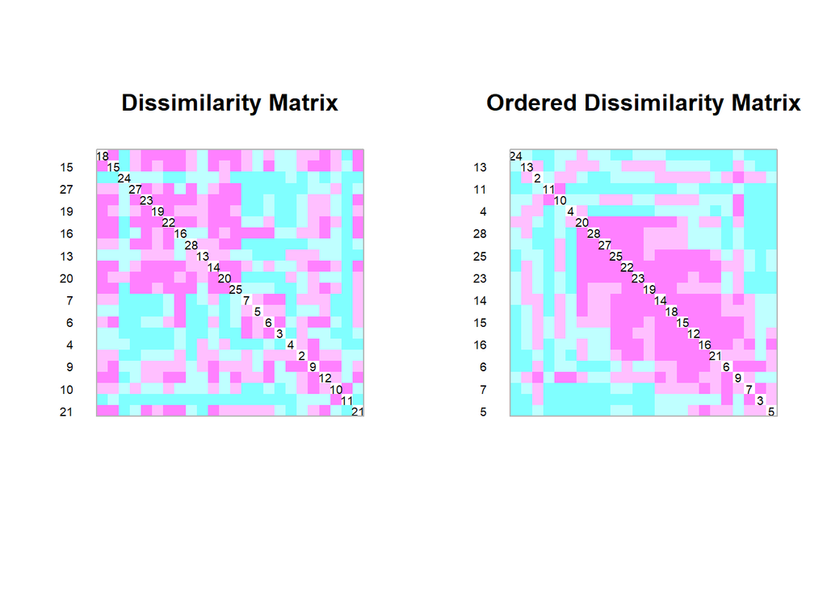

```r
coldiss(env.de, diag=T) # for the environmental data
```

In the untransformed distance matrix, the small differences in abundant species have the same importance as small differences in species with few individuals

Distance matrices are also commonly visualized through a network:

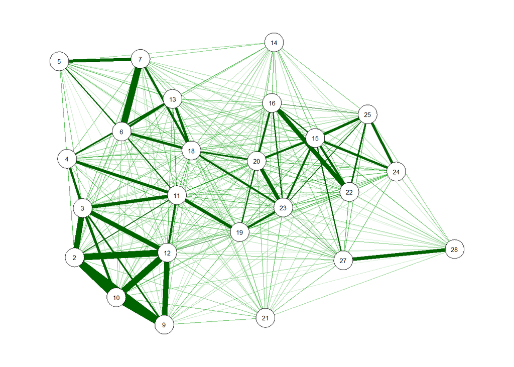

```r
qgraph(1-spe.db, layout='spring', vsize=4)
```

**Note 1**: In **Q mode** similarity from binary data can be interpret by a simple matching coefficient **S<sub>1</sub>**: for each pair of sites, it is the ratio between the number of double 1s plus double 0s and the total number of variables.

**Note 2**: For mixed types variables, including categorical or qualitative multiclass variables use **Gower’s similarity (S<sub>15</sub>)**. It is easily computed in R using `daisy` function built in the `cluster` package. Avoid `vegdist` with `method='gower'`, which is appropriate for quantitative and presence-absence, but not for multiclass variables. Overall, `gowdis` from the package `FD` is the most complete function to compute Gower’s coefficient in R, and commonly used in **trait-based approach** analyses.

### R mode

Correlation type coefficents are commonly used to compare variable in R mode. Remember:

- Parametric (*Pearson coefficient*)
- Non-parametric (*Spearman, Kendall for quantitative or semi-quantitative data*)
- *Chi-square* statistic + its derived forms for qualitative variables
- Binary coefficient such as *Jaccard*, *Sorensen*, and *Ochiai* for presence-absence data
- …

```r
spe.t <- t(spe)# transpose species matrix
spe.t.chi <- decostand(spe.t,'chi.square') # Chi-square transformation
spe.t.D16 <-dist(spe.t.chi)# euclidean distance
coldiss(spe.t.D16, diag=T) # visualization
```

[output not shown]

In R mode, the use of *Pearson* coefficient is very common. Applied on binary variables, r *Pearson* is called the **point correlation coefficient**. Using the function `panelutils` (Borcard et al. (2011):

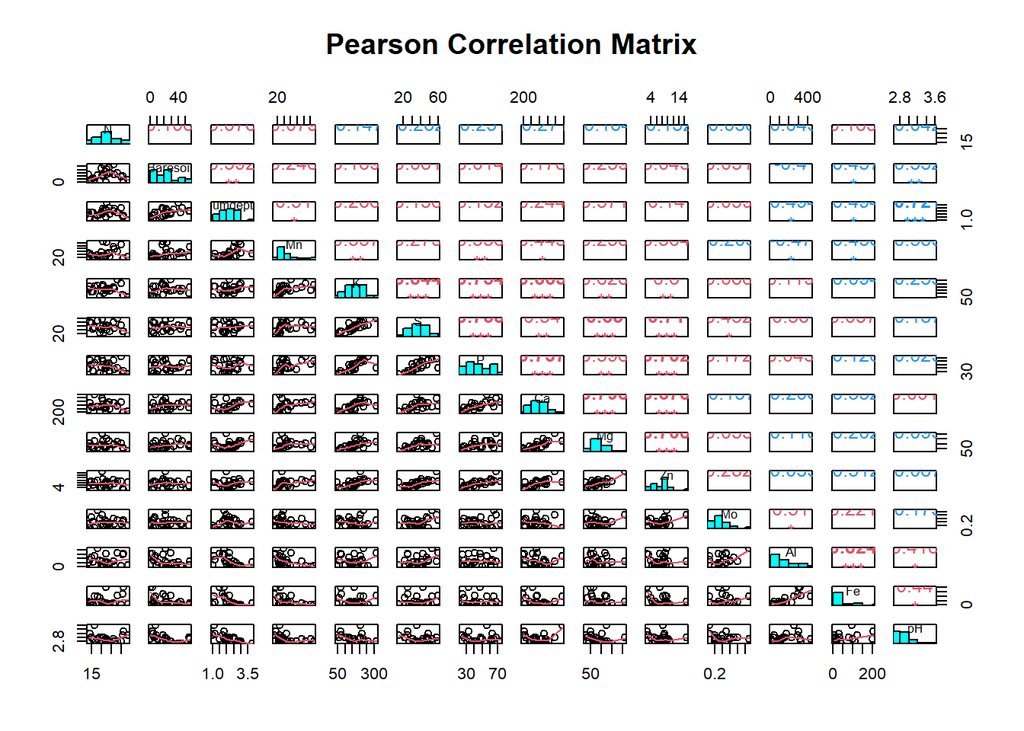

```r
#  Pearson r linear correlation among env. variable
env.pearson <- cor(env) # default method = 'pearson')
env.pearson <- round(env.pearson,2)
# re-order the variables prior to plotting
env.o<-order.single(env.pearson)
# need panelutils () on ceiba
source ('https://www.dipintothereef.com/uploads/3/7/3/5/37359245/panelutils.r')
pairs (env[,env.o], lower.panel=panel.smooth, upper.panel=panel.cor,diag.panel=panel.hist, main='Pearson Correlation Matrix')
```

> *RP16: Load `tikus` data set from the package `mvabund`. Extract coral species and environmental (years) data, and select samples from year 1981, 1983, and 1985 only.*
- *From the species data, calculate two distance matrices: (1) one using Bray-Curtis and, (2) one using Euclidean distance on log-transformed data*
- *Plot heat maps of respective matrix and compare. Briefly explain the differences.*

```r
library(mvabund)
data(tikus)
```

```r
# past code
```

## Cluster analysis

We often aim to recognize discontinuous **subsets** in an environment which is represented by discrete (taxonomy) changes but perceived as continuous changes in ecology.

**Clustering** consists in partitioning the collection of objects (or descriptors in R-mode). Clustering **does not test** any hypothesis.

**Clustering** is an explanatory procedure which helps to understand data with complex structure and multivariate relationships, and is a very useful method to extract knowledge and information especially from large datasets.

Many **clustering** approaches rely on association matrix, which stresses on the **importance** of the chhoice of a appropriate association coefficient.

### Families

1. **Sequential** or **Simultaneous** algorithms (most of the clustering algorithm)
2. **Agglomerative** or **Divisive**
3. **Monothetic** (common prop.) versus **Polythetic**
4. **Hierarchical** versus **Non-hierarchical** (flat)
5. **Probabilistic** (decision tree) versus **non-probabilistic** methods
6. **Hard** and **Soft** (may overlap)

Calculate numerical classification requires two arguments: matrix of distances among samples (ecological resemblance, D) and the method: name of clustering algorithm.

### R clustering

Common hierarchical clustering methods are available through the function `hclust` from the `stats` package

- **Data dredging** clustering produces tree-like structure. You don’t choose clustering method according to how your tree looks like.
- The suitable method is usually carefully **selected** and/or **evaluated** accoding to the data set you are dealing with and your hypotheses.

#### Hierarchical: common methods

- **Single linkage agglomerative clustering** (neighbor sorting)
  - commonly produced chain dendrograms: a pair is linked to a third object
  - agglomerates objects on the basis of their shortest pairwise distance
  - partitions difficult to interpret, but gradients quite clear

*e.g. Single linkage agglomerative clustering computed on chord distance matrix*

```r
# Step 1: chord distance = normalization + euclidean
spe.norm<-decostand(spe,'normalize')
spe.ch<-vegdist(spe.norm,'euc')
```

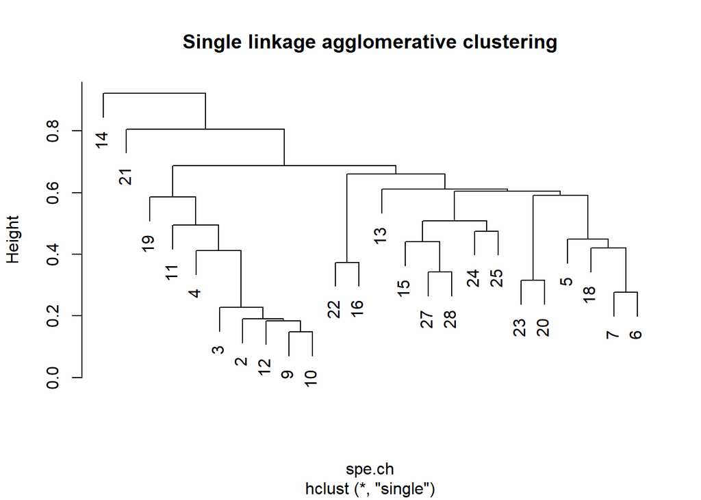

```r
# Step 2: single linkage agglomerative clustering
spe.ch.single <-hclust(spe.ch,method='single')
# plot function
plot(spe.ch.single, main='Single linkage agglomerative clustering' )
```

Single linkage allows object to agglomerate easily to a group since a link to a single object of the group suffices to induce fusion. **This is the ‘closest’ friend’ procedure**.

- **Complete linkage agglomerative clustering** (furthest neighbor sorting)
  - dendrograms look a bit like rakes – some cluster merge together at the highest dissimilarity
  - allow an object (or a group) to agglomerate with another group only at the distance corresponding to that of the most distant pair of objects

*e.g. Complete linkage agglomerative clustering computed on chord distance matrix*

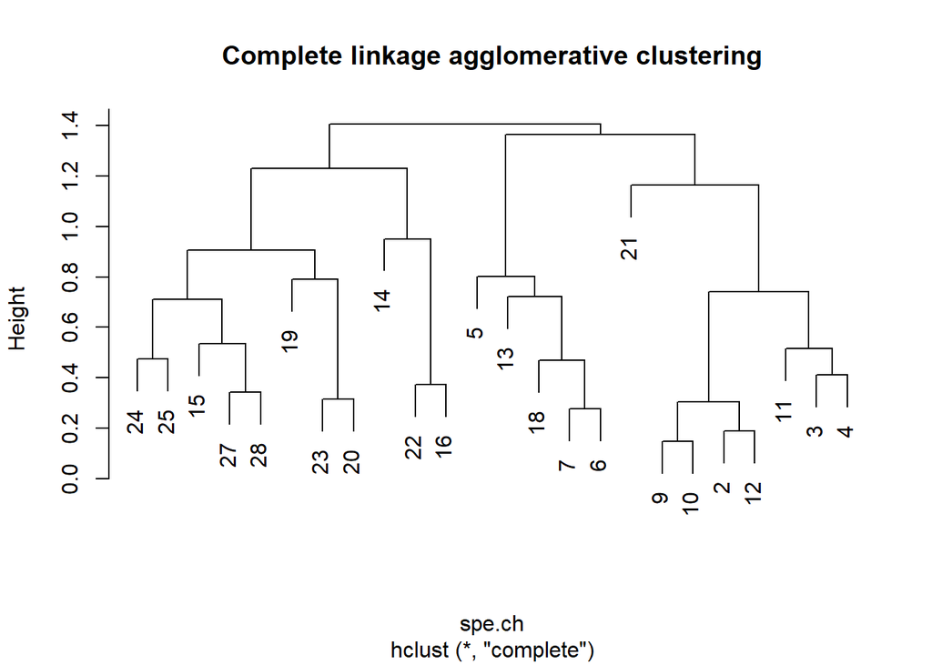

```r
spe.ch.complete<-hclust(spe.ch,method='complete')
plot(spe.ch.complete, main='Complete linkage agglomerative clustering')
```

A group admits a new member only at the distance corresponding to the furthest object of the group: **one could say that the admission requires unanimity of the group**.

- **Average agglomerative clustering**
  - it is the method the **most common** in ecology (species data)
  - this family comprises **four methods** that are based on **average** dissimilarities among objects or on the **centroids** of cluster,

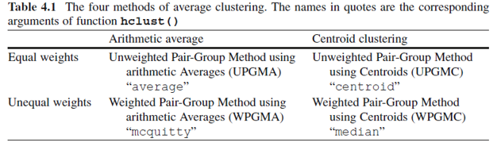

*e.g. Average agglomerative clustering (UPGMA) computed on chord distance matrix*

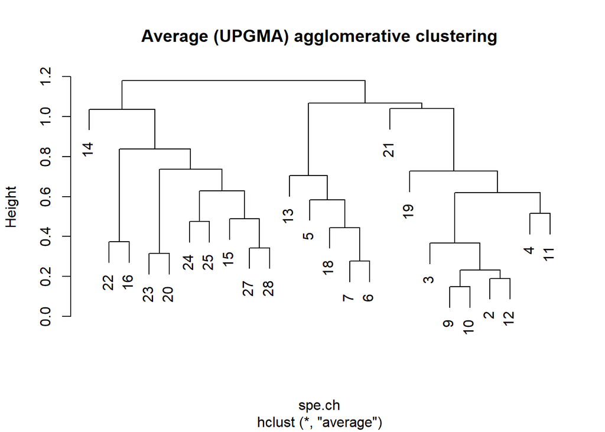

```r
spe.ch.UPGMA<-hclust(spe.ch,method='average')
plot(spe.ch.UPGMA, main='Average (UPGMA) agglomerative clustering')
```

- **Ward’s Minimum Variance clustering**
- **Ward** method is also a favorite clustering method
- it is based on linear model criterion of least square: within-group sum of square (i.e. the square error of ANOVA) is minimized.

**Note**: Ward method is based on Euclidean model. It should not be combined with distance measures, which are not strictly metric such as the popular Bray-Curtis distance.

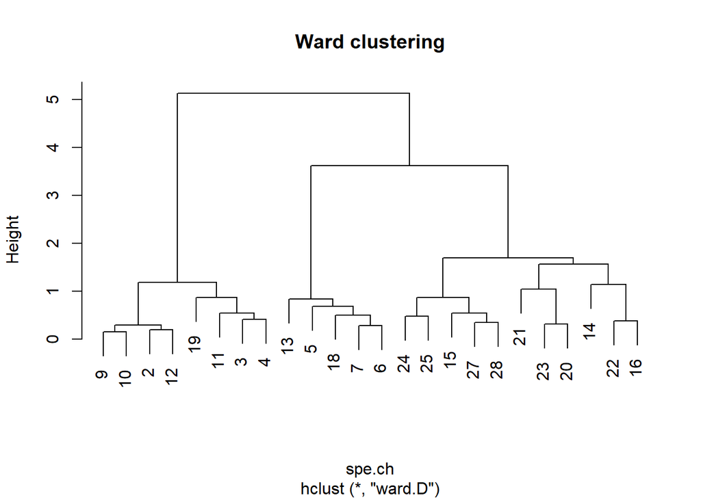

```r
spe.ch.ward<-hclust(spe.ch,method='ward.D')
plot(spe.ch.ward, main='Ward clustering')
```

- **Flexible clustering**

`hclust` is called in this algorithm, but flexible clustering is available in the R package `cluster` with the function `agnes`

- *Beta flexible* methods
- Model encompassing all the clustering methods seen before, which are obtained by changing the values of four parameters

#### Quality clustering

There are many ways to evaluate the overall quality of the chose clustering algorithm and therefore their representations.

- the **cophenetic correlation** related distances extracted from the dendrogram (function `cophenetic` on a `hclust` object) with ditances in our original distance matrices. A higher correlation means a better representation of the initial matrix.

```r
# Single linkage clustering
spe.ch.single.coph <- cophenetic (spe.ch.single)
cor(spe.ch,spe.ch.single.coph)
```

```
## [1] 0.6684868
```

```r
# complete linkage clustering
spe.ch.complete.coph <- cophenetic (spe.ch.complete)
cor(spe.ch,spe.ch.complete.coph)
```

```
## [1] 0.8212132
```

```r
# Average clustering
spe.ch.UPGMA.coph <- cophenetic (spe.ch.UPGMA)
cor(spe.ch,spe.ch.UPGMA.coph)
```

```
## [1] 0.8586625
```

```r
# Ward clustering
spe.ch.ward.coph <- cophenetic (spe.ch.ward)
cor(spe.ch,spe.ch.ward.coph)
```

```
## [1] 0.716064
```

- the **shepard-like diagram** is a plot that represents orginal distances against the cophentic distances. Can be combined with cophentic correlation seen above.

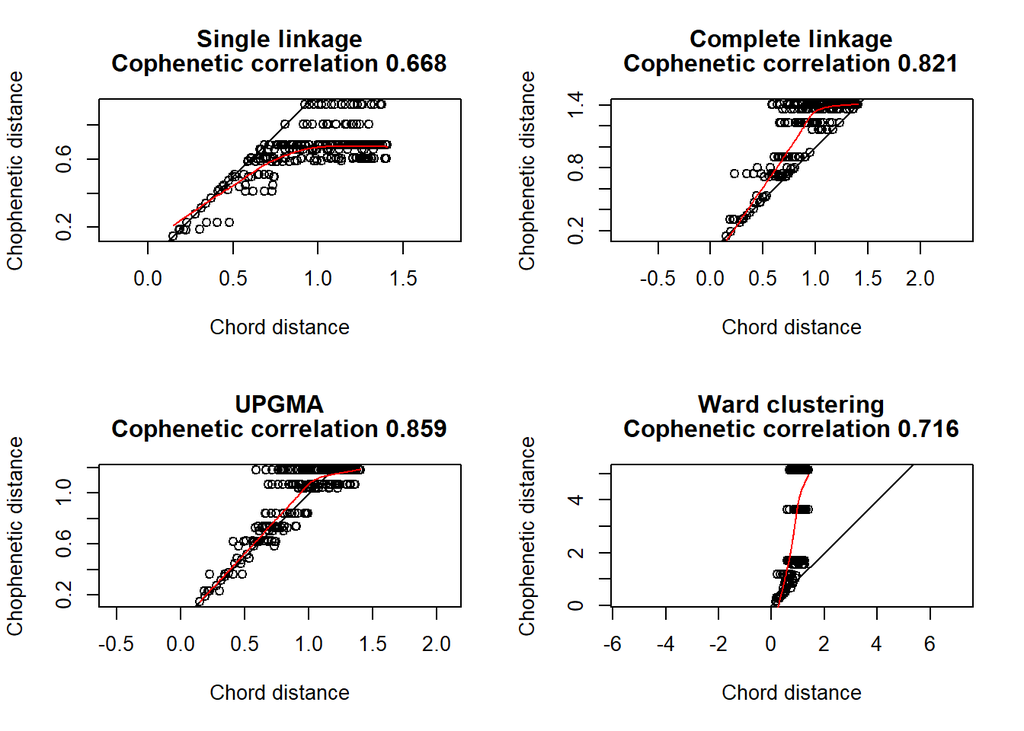

```r
par(mfrow=c(2,2))

plot(spe.ch,spe.ch.single.coph,xlab='Chord distance',ylab='Chophenetic distance',asp=1, main=c('Single linkage',paste('Cophenetic correlation',round(cor(spe.ch,spe.ch.single.coph),3))))
abline (0,1)
lines(lowess(spe.ch,spe.ch.single.coph),col='red')

plot(spe.ch,spe.ch.complete.coph,xlab='Chord distance',ylab='Chophenetic distance',asp=1, main=c('Complete linkage',paste('Cophenetic correlation',round(cor(spe.ch, spe.ch.complete.coph),3))))
abline (0,1)
lines(lowess(spe.ch, spe.ch.complete.coph),col='red')

plot(spe.ch,spe.ch.UPGMA.coph,xlab='Chord distance',ylab='Chophenetic distance',asp=1, main=c('UPGMA',paste('Cophenetic correlation',round(cor(spe.ch,spe.ch.UPGMA.coph),3))))
abline (0,1)
lines(lowess(spe.ch,spe.ch.UPGMA.coph),col='red')

plot(spe.ch,spe.ch.ward.coph,xlab='Chord distance',ylab='Chophenetic distance',asp=1, main=c('Ward clustering',paste('Cophenetic correlation',round(cor(spe.ch,spe.ch.ward.coph),3))))
abline (0,1)
lines(lowess(spe.ch,spe.ch.ward.coph),col='red')
```

```r
dev.off()
```

- the **Fusion Level Values**. Examine values where a fusion between two branches of a dendrogram occurs. This graph is useful whenver you want to define an interpretable cutting levels.

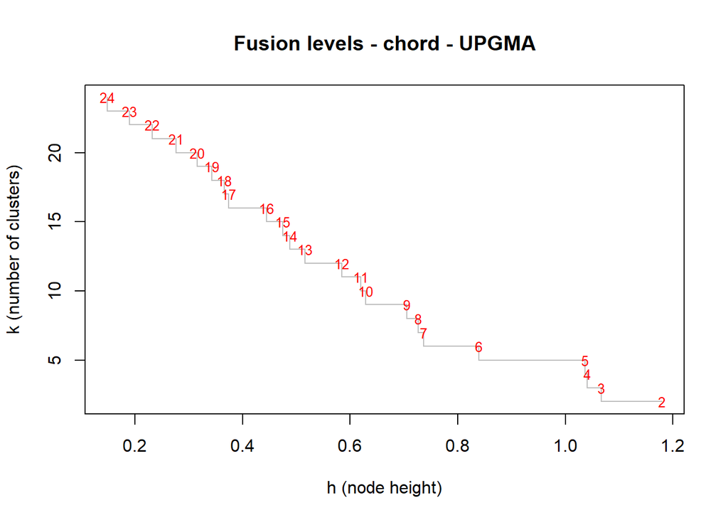

```r
plot(spe.ch.UPGMA$height, nrow(spe):2,
     type='S',main='Fusion levels - chord - UPGMA',
     ylab='k (number of clusters)', xlab='h (node height)', col='grey')
text (spe.ch.UPGMA$height,nrow(spe):2, nrow(spe):2, col='red', cex=0.8)
```

The graph of fusion level values shows clear jump after each fusion between 2 and 6 groups Let’s cut our dendrogram at the corresponding distance Do the groups makes sense? Do you obtain groups containing a substantial number of sites?

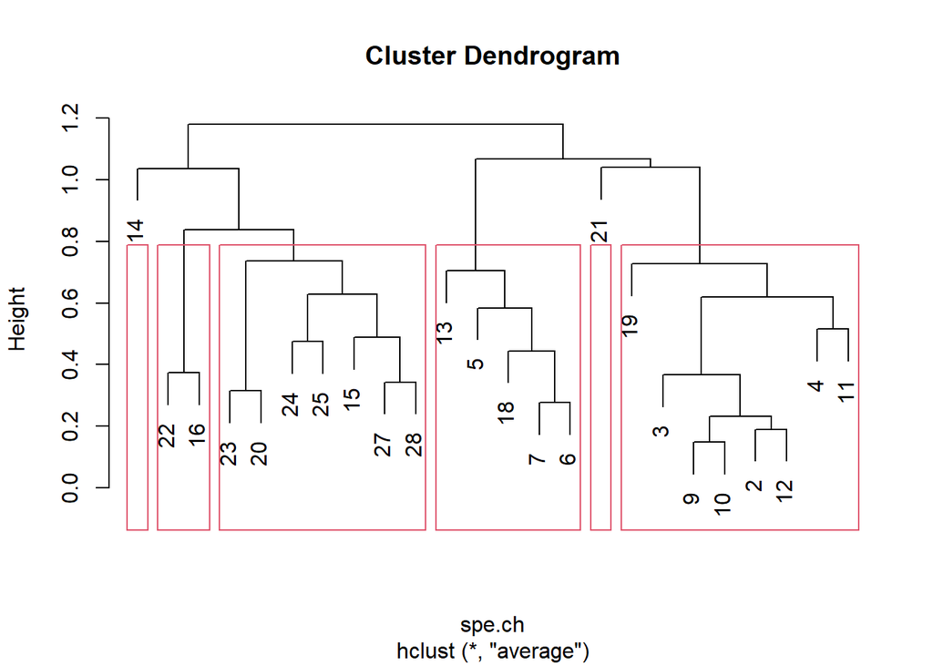

```r
plot(spe.ch.UPGMA)
rect.hclust(spe.ch.UPGMA, k=6) # number of group
rect.hclust(spe.ch.UPGMA, h=0.79) # with height
```

Let’s repeat the same for all the clustering methods:

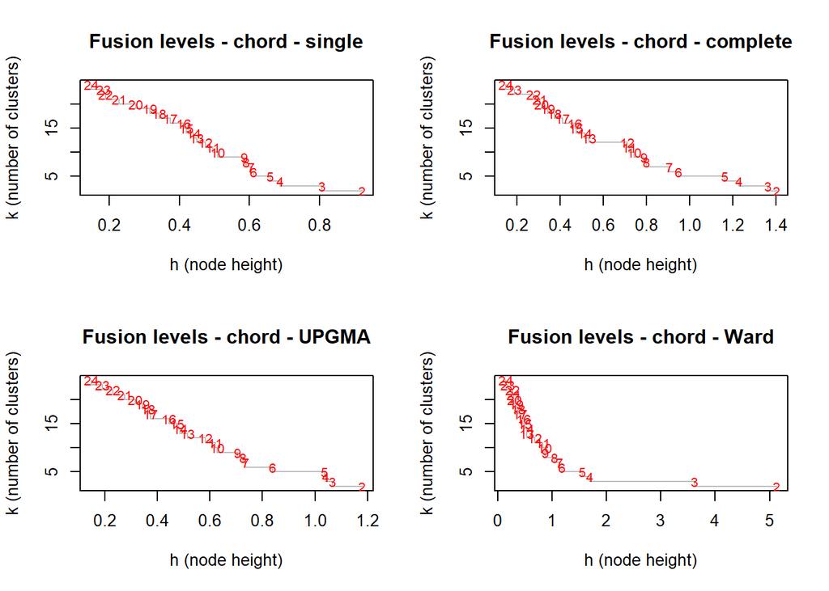

```r
par(mfrow=c(2,2))
# fusion level - single linkage clustering
plot(spe.ch.single$height,
     nrow(spe):2, type='S',main='Fusion levels - chord - single',
     ylab='k (number of clusters)', xlab='h (node height)', col='grey')
text (spe.ch.single$height,nrow(spe):2, nrow(spe):2, col='red', cex=0.8)

# fusion level - complete linkage clustering
plot(spe.ch.complete$height,
     nrow(spe):2, type='S',main='Fusion levels - chord - complete',
     ylab='k (number of clusters)', xlab='h (node height)', col='grey')
text (spe.ch.complete$height,nrow(spe):2, nrow(spe):2, col='red', cex=0.8)

# fusion level - UPGMA clustering
plot(spe.ch.UPGMA$height, nrow(spe):2,
     type='S',main='Fusion levels - chord - UPGMA',
     ylab='k (number of clusters)', xlab='h (node height)', col='grey')
text (spe.ch.UPGMA$height,nrow(spe):2, nrow(spe):2, col='red', cex=0.8)

# fusion level - the ward clustering
plot(spe.ch.ward$height, nrow(spe):2,
     type='S',main='Fusion levels - chord - Ward',
     ylab='k (number of clusters)', xlab='h (node height)', col='grey')
text (spe.ch.ward$height,nrow(spe):2, nrow(spe):2, col='red', cex=0.8)
```

All graphs look a but different: there is no single ‘truth’ among these solution and each may provide insight onto the data. However the Chord UPGMA received the best supported in both the cophenetic correlation and sheppard-like diagram. Therefore, fusion levels may have have a stronger support examined with this cluster approach.

One can compared classification by cutting tree `cutree` and comparing grouping using contingency tables:

```r
k<-5 # Number of groups (conscensus)
spebc.single.g <- cutree(spe.ch.single, k)
spebc.complete.g <- cutree(spe.ch.complete, k)
spebc.UPGMA.g <- cutree(spe.ch.UPGMA, k)
spebc.ward.g <- cutree(spe.ch.ward, k)

table(spebc.single.g,spebc.complete.g) # Single vs complete
```

```
##               spebc.complete.g
## spebc.single.g 1 2 3 4 5
##              1 5 7 0 0 0
##              2 0 1 0 7 0
##              3 0 0 2 0 0
##              4 0 0 1 0 0
##              5 0 0 0 0 1
```

If two classifications provided the same group contents, the contingency table would show only non zero frequency value in each row and each column0 It is never the case here.

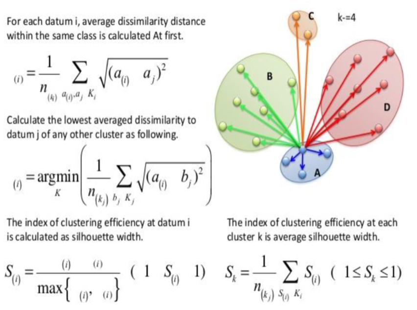

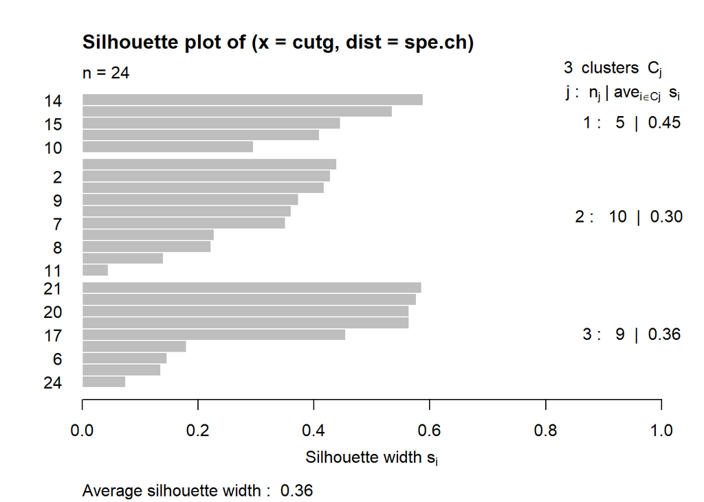

```r
cutg<-cutree(spe.ch.UPGMA, k=3)
sil<-silhouette (cutg,spe.ch)
plot(sil)
```

- the **Mantel** test
  - Compares the original distance matrix to binary matrices computed from dendrogram cut at various level
  - Chooses the level where the matrix ( correlation between the two is the highest
  - The Mantel correlation is in its simplest sense, i.e. the equivalent of a Pearson r correlation between the values in the distance matrices

Comparison between the distance matrix and binary matrices representing partitions

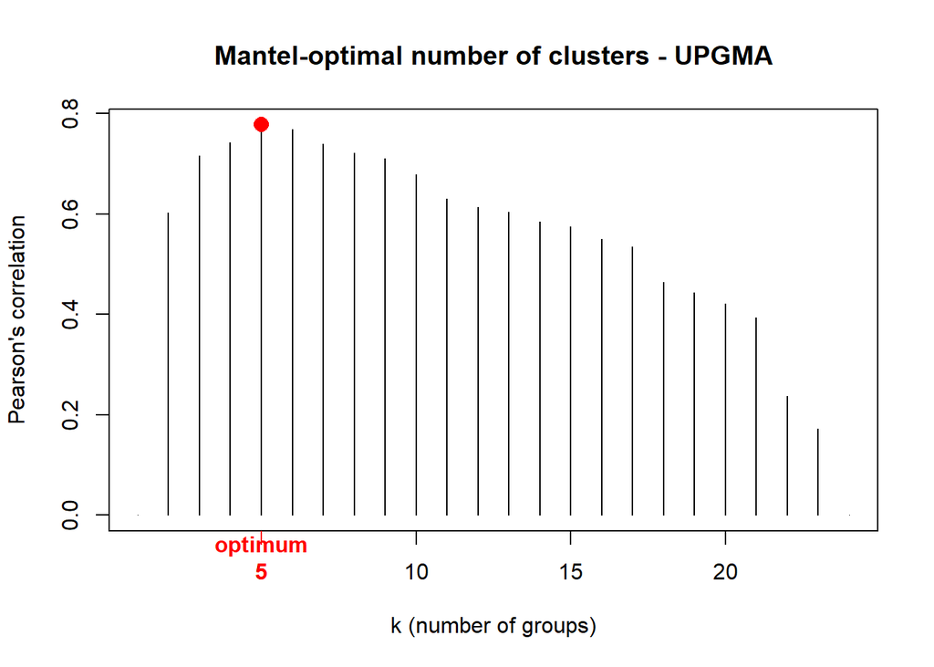

```r
## Mantel test
# Optimal number of clusters
# according to mantel statistic
# Function to compute a binary distance matrix from groups
grpdist<-function(x){
  require (cluster)
  gr<-as.data.frame(as.factor(x))
  distgr<-daisy(gr,'gower')
  distgr
}
# run based on the UPGMA clustering
kt<-data.frame(k=1:nrow(spe),r=0)
for (i in 2:(nrow(spe)-1)){
  gr<-cutree(spe.ch.UPGMA,i)
  distgr<-grpdist(gr)
  mt<-cor(spe.ch,distgr, method='pearson')
  kt[i,2] <- mt
}
k.best <- which.max (kt$r)
plot(kt$k,kt$r,
     type='h', main='Mantel-optimal number of clusters - UPGMA',
     xlab='k (number of groups)',ylab="Pearson's correlation")
axis(1,k.best,
     paste('optimum', k.best, sep='\n'), col='red',font=2, col.axis='red')
points(k.best,max(kt$r),pch=16,col='red',cex=1.5)
```

- the **Elbow** method
  - This method looks at the percentage of variance explained (SS) as a function of the number of cluster
  - One should choose a number of clusters so that adding another cluster doesn’t give much better explanation

At some point the marginal gain will drop, giving an angle in the graph. The number of clusters is chosen at this point, hence the “elbow criterion”.

Using **fuzzy clustering** *(also referred to as soft clustering or soft k-means) is a form of clustering in which each data point can belong to more than one cluster)*

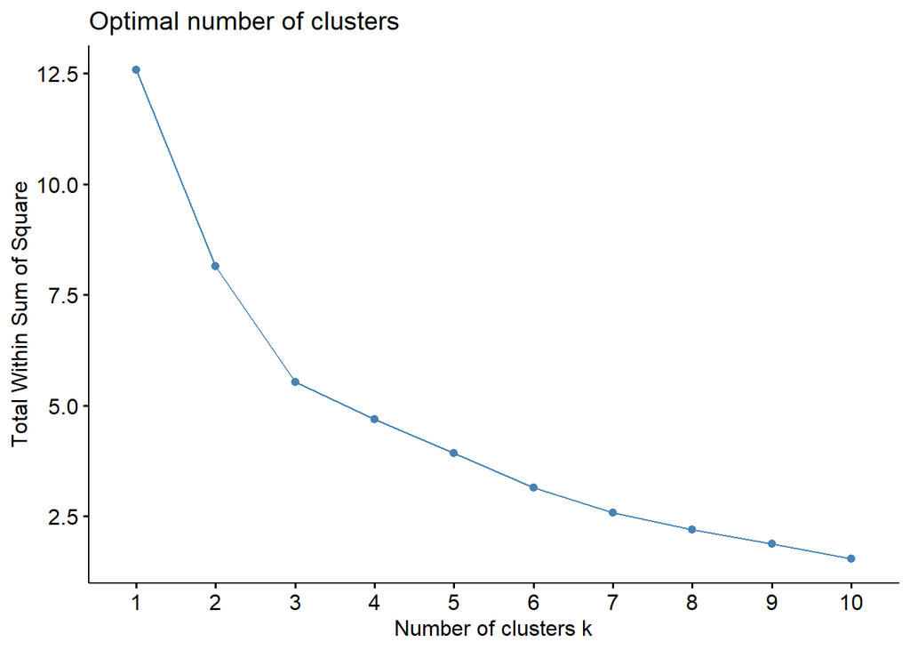

```r
fviz_nbclust(spe.norm, hcut, method = "wss",hc_method = "average")
```

```r
# fviz_nbclust(spe.norm, hcut, method = "silhouette",hc_method = "average")
```

- And many others indicators